# HSC Survey Results

# German Bank Survey # 4 Results from 13/09/2023

## Survey Details

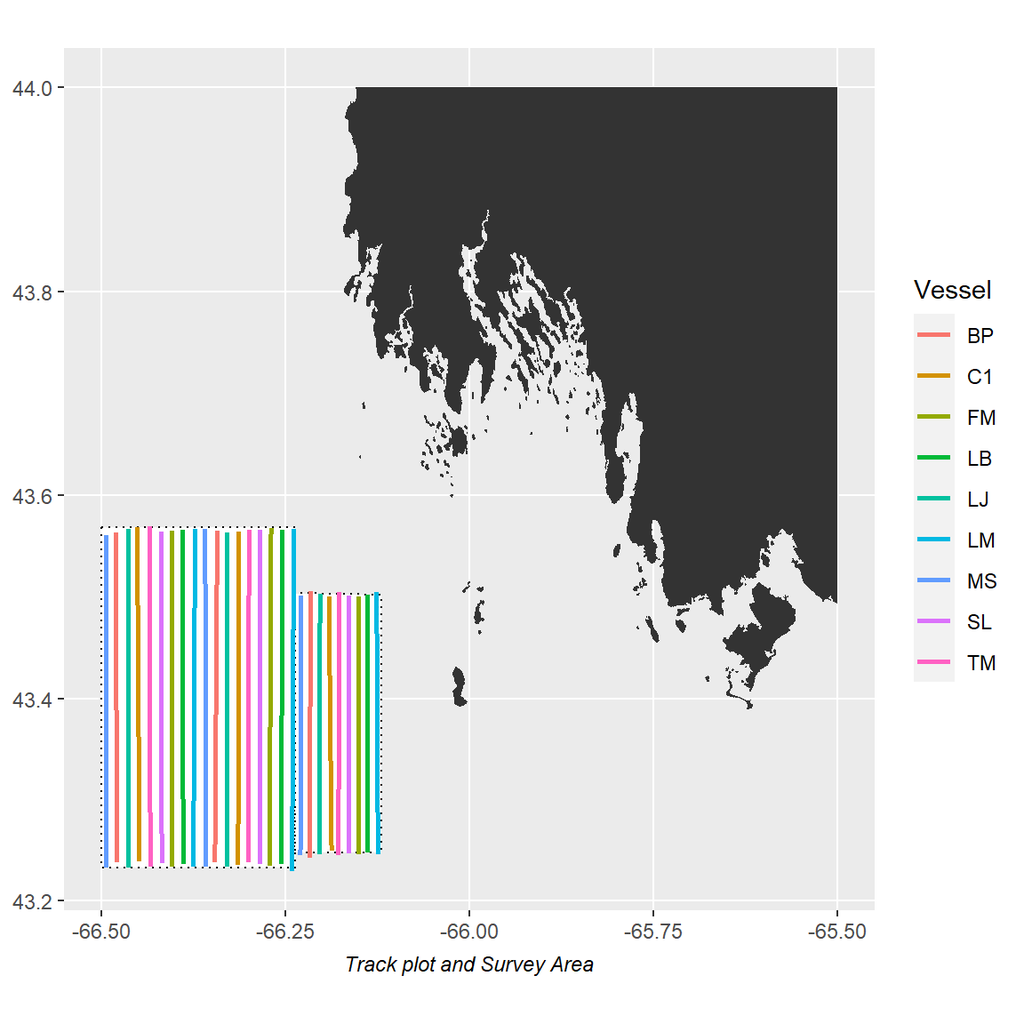

9 commercial purse seiners conducted this fishing survey on 13/09/2023 starting at 20:30:00.

All vessels ran two transects in the German Bank box and one transect in the Seal Island Box.

There was a plankton tow and replicate conducted and CTD cast by Lady Melissa.

A total of 700 tags were applied during the survey over 3 event(s) from 2023-09-14 to 2023-09-18 from 1 vessel(s).

Since no fish were caught, no samples were obtained for target strength estimation.

### Acoustic Equipment

Each vessel was equipped with a Simrad ES38-18/200-18C combi (2-in-1) transducer prior to the survey that contains a 38kHz split beam and 200 kHz single beam transducer. Data was logged to the computer hard-drive for post-processing. All participating boats were calibrated on 38kHz before the survey.

## Survey Results

### Main Results

The results are subject to change as DFO will re-evaluate data editing, area estimation and apply a target strength.

**Preliminary biomass prediction for German Bank using standardized parallel transects is 16,266mt, and with turnover applied 13,203mt. The preliminary biomass estimate for Seal Island is 5,636mt.**

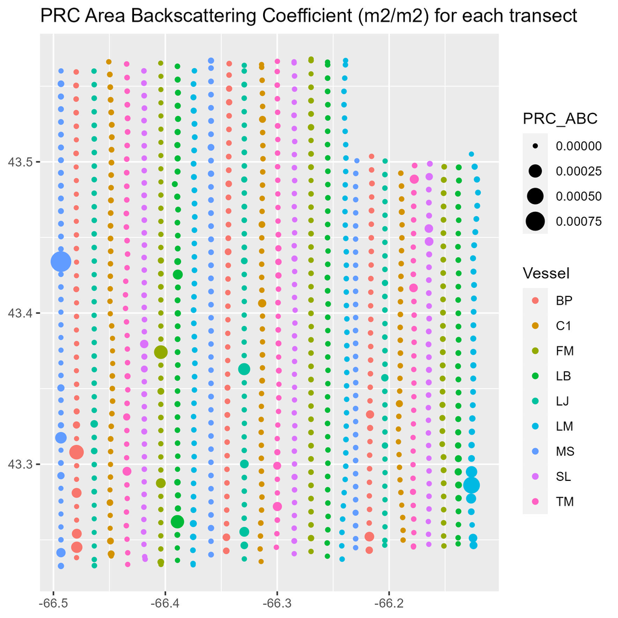

### Transect Details

Table 1: Transect Details

| Vessel | Transect # | Date/Time Start | Date/Time End | Start Lon | Start Lat | End Lon | End Lat | Location | Distance (km) | Speed |
| --- | --- | --- | --- | --- | --- | --- | --- | --- | --- | --- |
| BP | T01 | 2023-09-14 01:15:17 | 2023-09-14 03:36:39 | -66.480 | 43.564 | -66.479 | 43.238 | GB | 36.22 | 8.30 |
| BP | T02 | 2023-09-14 04:18:30 | 2023-09-14 06:37:54 | -66.346 | 43.238 | -66.343 | 43.565 | GB | 36.34 | 8.45 |
| BP | T03 | 2023-09-14 07:16:07 | 2023-09-14 09:11:29 | -66.216 | 43.505 | -66.218 | 43.243 | GB | 29.24 | 8.21 |
| C1 | T01 | 2023-09-14 00:23:38 | 2023-09-14 02:46:42 | -66.451 | 43.569 | -66.448 | 43.239 | GB | 39.55 | 8.96 |
| C1 | T02 | 2023-09-14 03:28:28 | 2023-09-14 05:45:32 | -66.314 | 43.235 | -66.314 | 43.564 | GB | 38.25 | 9.04 |
| C1 | T03 | 2023-09-14 06:20:59 | 2023-09-14 08:08:37 | -66.191 | 43.500 | -66.188 | 43.250 | GB | 29.75 | 8.96 |
| FM | T01 | 2023-09-14 01:23:15 | 2023-09-14 03:47:50 | -66.404 | 43.566 | -66.404 | 43.234 | GB | 38.21 | 8.56 |
| FM | T02 | 2023-09-14 04:29:49 | 2023-09-14 06:51:19 | -66.272 | 43.235 | -66.270 | 43.568 | GB | 37.99 | 8.70 |
| FM | T03 | 2023-09-14 07:27:12 | 2023-09-14 09:13:28 | -66.151 | 43.501 | -66.151 | 43.246 | GB | 29.19 | 8.90 |
| LB | T01 | 2023-09-14 00:18:48 | 2023-09-14 03:05:35 | -66.389 | 43.566 | -66.389 | 43.236 | GB | 38.26 | 7.43 |
| LB | T02 | 2023-09-14 03:56:29 | 2023-09-14 06:11:19 | -66.255 | 43.236 | -66.255 | 43.566 | GB | 37.51 | 9.01 |
| LB | T03 | 2023-09-14 06:49:17 | 2023-09-14 08:34:02 | -66.138 | 43.502 | -66.138 | 43.247 | GB | 29.08 | 8.99 |
| LJ | T01 | 2023-09-14 00:22:52 | 2023-09-14 02:47:34 | -66.464 | 43.567 | -66.463 | 43.233 | GB | 37.18 | 8.32 |
| LJ | T02 | 2023-09-14 03:29:52 | 2023-09-14 05:50:44 | -66.330 | 43.233 | -66.329 | 43.564 | GB | 36.87 | 8.48 |
| LJ | T03 | 2023-09-14 06:30:24 | 2023-09-14 08:17:40 | -66.203 | 43.503 | -66.204 | 43.246 | GB | 28.66 | 8.65 |
| LM | T01 | 2023-09-14 00:11:22 | 2023-09-14 02:37:56 | -66.373 | 43.567 | -66.375 | 43.233 | GB | 37.83 | 8.36 |
| LM | T02 | 2023-09-14 03:18:27 | 2023-09-14 05:44:44 | -66.241 | 43.229 | -66.239 | 43.567 | GB | 38.22 | 8.47 |
| LM | T03 | 2023-09-14 06:16:46 | 2023-09-14 08:08:21 | -66.126 | 43.505 | -66.125 | 43.246 | GB | 29.55 | 8.58 |
| MS | T01 | 2023-09-14 00:23:30 | 2023-09-14 03:05:49 | -66.493 | 43.561 | -66.493 | 43.233 | GB | 39.09 | 7.80 |
| MS | T02 | 2023-09-14 03:53:50 | 2023-09-14 06:06:23 | -66.358 | 43.234 | -66.359 | 43.567 | GB | 38.34 | 9.37 |
| MS | T03 | 2023-09-14 06:53:45 | 2023-09-14 08:37:19 | -66.229 | 43.501 | -66.230 | 43.245 | GB | 29.73 | 9.30 |
| SL | T01 | 2023-09-14 01:20:01 | 2023-09-14 03:47:00 | -66.419 | 43.564 | -66.418 | 43.237 | GB | 39.68 | 8.75 |
| SL | T02 | 2023-09-14 04:29:27 | 2023-09-14 06:48:08 | -66.284 | 43.236 | -66.285 | 43.566 | GB | 38.61 | 9.02 |
| SL | T03 | 2023-09-14 07:23:06 | 2023-09-14 09:09:50 | -66.164 | 43.501 | -66.165 | 43.247 | GB | 30.06 | 9.12 |
| TM | T01 | 2023-09-14 00:11:45 | 2023-09-14 02:53:05 | -66.435 | 43.570 | -66.434 | 43.234 | GB | 37.48 | 7.53 |
| TM | T02 | 2023-09-14 03:37:51 | 2023-09-14 05:55:47 | -66.300 | 43.238 | -66.300 | 43.566 | GB | 36.58 | 8.59 |
| TM | T03 | 2023-09-14 06:33:07 | 2023-09-14 08:24:02 | -66.177 | 43.505 | -66.178 | 43.245 | GB | 28.87 | 8.43 |

### Survey Summary

Table 2: Acoustic Survey Results

| Vessel | Transect No. | Target Strength (db/kg) | Mean Sa (/m2) | Biomass Density (kg/m2) |
| --- | --- | --- | --- | --- |
| MS | T01 | -35.5 | -44.990 | 0.112 |
| LM | T03 | -35.5 | -45.139 | 0.109 |
| BP | T01 | -35.5 | -47.406 | 0.064 |
| LB | T01 | -35.5 | -49.462 | 0.040 |
| FM | T01 | -35.5 | -49.692 | 0.038 |
| LJ | T02 | -35.5 | -49.926 | 0.036 |
| BP | T03 | -35.5 | -52.968 | 0.018 |
| SL | T03 | -35.5 | -53.250 | 0.017 |
| TM | T03 | -35.5 | -53.753 | 0.015 |
| TM | T02 | -35.5 | -54.719 | 0.012 |
| LB | T03 | -35.5 | -55.028 | 0.011 |
| TM | T01 | -35.5 | -56.109 | 0.009 |
| BP | T02 | -35.5 | -56.330 | 0.008 |
| SL | T01 | -35.5 | -56.336 | 0.008 |
| C1 | T02 | -35.5 | -56.992 | 0.007 |
| LM | T01 | -35.5 | -57.638 | 0.006 |
| FM | T03 | -35.5 | -58.082 | 0.006 |
| MS | T02 | -35.5 | -58.125 | 0.005 |
| C1 | T01 | -35.5 | -58.322 | 0.005 |
| LJ | T03 | -35.5 | -58.375 | 0.005 |
| LJ | T01 | -35.5 | -58.652 | 0.005 |
| FM | T02 | -35.5 | -59.540 | 0.004 |
| C1 | T03 | -35.5 | -60.115 | 0.003 |
| LB | T02 | -35.5 | -61.538 | 0.002 |
| MS | T03 | -35.5 | -62.081 | 0.002 |
| SL | T02 | -35.5 | -62.297 | 0.002 |
| LM | T02 | -35.5 | -62.715 | 0.002 |

Note:  
Transects are listed from greatest to least backscatter.

Table 3: Survey Summary Table

| Layer | Target Strength | Area (km2) | Mean Sa | Density (kg/m2) | Biomass (tons) | Percent Area | Percent Biomass | Standard Error (tons) | Standard Error (%) |
| --- | --- | --- | --- | --- | --- | --- | --- | --- | --- |
| German Bank | -35.5 | 796 | -52.3964 | 0.0204 | 16,265.846 | NA | NA | 5,425.42 | 33.35 |
| Seal Island | -35.5 | 272 | -52.3362 | 0.0206 | 5,635.715 | NA | NA | 3,040.76 | 53.96 |
| School Survey | NA | NA | NA | NA | NA | NA | NA | NA | NA |

### Greatest Biomass Densities

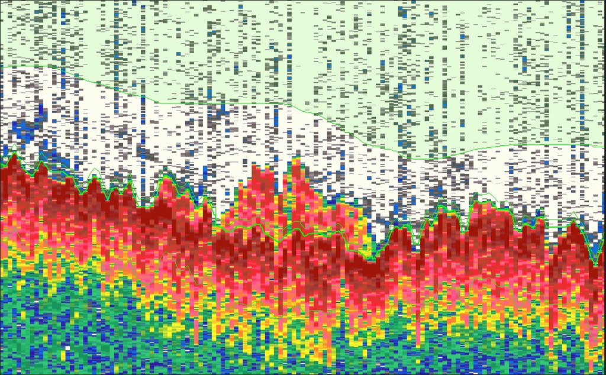

A snip from the transect with the greatest biomass density (kg/m2)

The single point with the largest biomass density (kg/m2) was recorded by **MS**, at the following location:

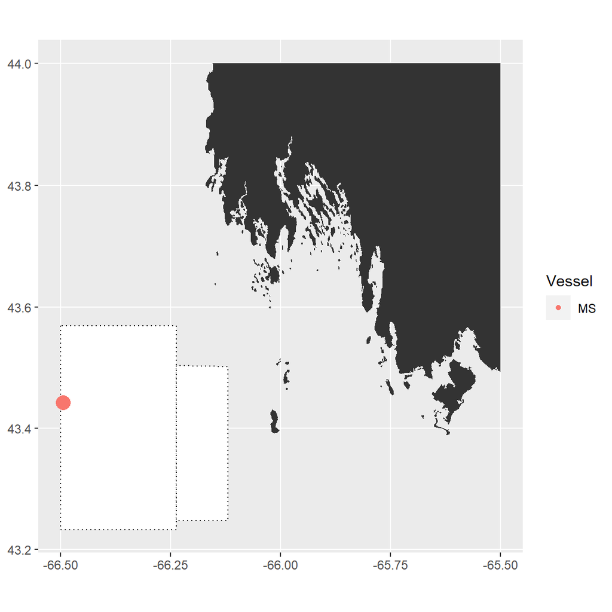

The transect with the greatest average biomass density (kg/m2) was recorded by **MS**, at the following location:

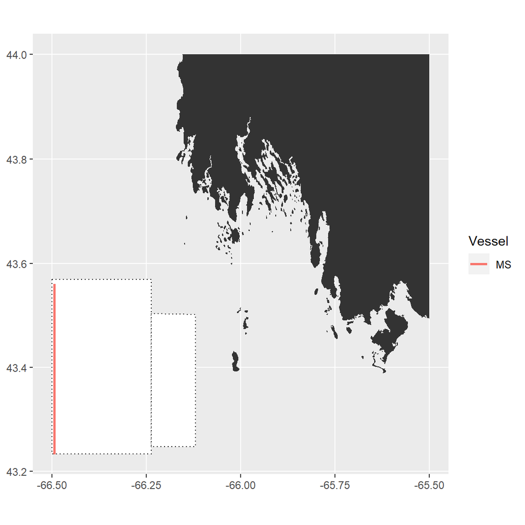

### Annual Summaries

Table 4: Annual Comparison Table

| Ground | Survey Number | Current Year Survey Date | Current Year HSC Estimate | Current Year HSC Turnover Adjusted | Previous Year Survey Date | Previous Year HSC Estimate | Previous Year HSC Turnover Adjusted | Previous Year DFO Estimate | Previous Year DFO Turnover Adjusted |
| --- | --- | --- | --- | --- | --- | --- | --- | --- | --- |
| German Bank | 1 | 2023-08-06 | 2,686.514 | NA | 2022-08-14 | 16,285 | 16,285 | 22,081 | 22,081 |
| German Bank | 2 | 2023-08-20 | 4,930.454 | 4,406.486 | 2022-08-28 | 7,472 | 4,296 | 11,699 | 7,393 |
| German Bank | 3 | 2023-09-03 | 9,959.441 | 8,901.000 | 2022-09-11 | 12,507 | 10,464 | 11,902 | 8,826 |
| German Bank | 4 | 2023-09-13 | 16,265.846 | 13,203.000 | 2022-09-25 | 15,924 | 13,216 | 12,503 | 9,761 |
| Seal Island | 1 | 2023-08-06 | 1,205.361 | NA | 2022-08-14 | 2,598 | 2,598 | 2,086 | 2,086 |
| Seal Island | 2 | 2023-08-20 | 1,917.847 | NA | 2022-08-28 | 1,048 | 1,048 | 570 | 570 |
| Seal Island | 3 | 2023-09-03 | 2,062.584 | NA | 2022-09-11 | 6,941 | 6,941 | 6,392 | 6,392 |
| Seal Island | 4 | 2023-09-13 | 5,635.715 | NA | 2022-09-25 | 4,634 | 4,634 | 3,732 | 3,732 |
| German Bank | 5 | NA | NA | NA | 2022-10-10 | 19,539 | 16,337 | 20,247 | 17,675 |
| German Bank | 6 | NA | NA | NA | 2022-10-23 | 13,399 | 8,684 | 15,565 | 10,823 |
| Seal Island | 5 | NA | NA | NA | 2022-10-10 | 5,243 | 5,243 | 5,604 | 5,604 |
| Seal Island | 6 | NA | NA | NA | 2022-10-23 | 2,944 | 2,944 | 3,260 | 3,260 |

Table 5: Annual Summary Table

| Year | Ground | HSC Estimate | HSC Turnover Adjusted | DFO Estimate | DFO Turnover Adjusted |
| --- | --- | --- | --- | --- | --- |
| 2022 | German Bank | 85,126.00 | 69,282 | 93,997 | 76,559 |
| 2022 | Seal Island | 23,408.00 | 23,408 | 21,644 | 21,644 |
| 2023 | German Bank | 33,842.26 | NA | NA | NA |
| 2023 | Seal Island | 10,821.51 | NA | NA | NA |

## Tagging, Plankton, and CTD Data

### Tag Data

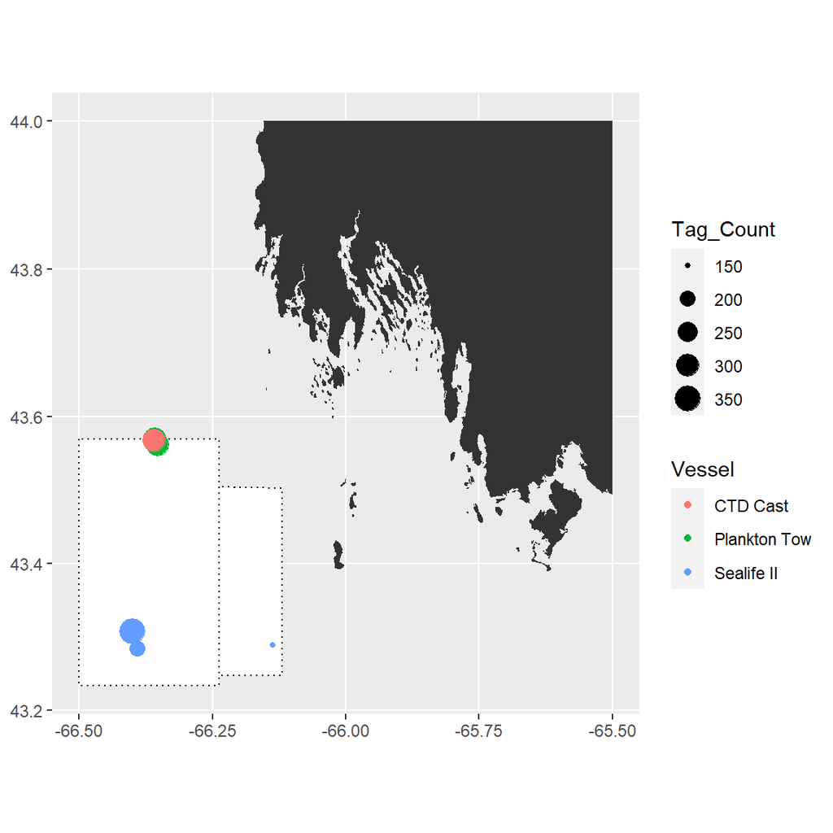

| Vessel | Tags |
| --- | --- |
| Sealife II | 700 |

### Plankton Data

#### Tow Summary Table

|  | Tow 1 | Tow 2 |
| --- | --- | --- |
| **Base Details** |  |  |
| Vessel | Lady Melissa | Lady Melissa |
| Set Number | GB2023-07 | GB2023-08 |
| Ground | GB | GB |
| Date | 13/09/2023 | 13/09/2023 |
| Wind Direction (km/h) | SE | SE |
| Swell (m) | 0.5 | 0.5 |
| Air Temp (c) | 18 | 18 |
| **Tow Details** |  |  |
| Tow Start | 19:41:00 | 19:57:00 |
| Tow End | 19:51:00 | 20:07:00 |
| Start Lat | 43.56917 | 43.56100 |
| End Lat | 43.57483 | 43.57767 |
| Start Lon | -66.35833 | -66.35233 |
| End Lon | -66.35950 | -66.35283 |
| Avg Tow Depth (m) | 2.742925 | 1.483087 |
| Speed | 4.7 | 5.6 |
| Heading | 180 | 0 |
| Tide Direction | with | against |
| **Other Data Collection** |  |  |
| Flow Start | 213098 | 265770 |
| Flow End | 265770 | 320580 |
| No. Revolutions | 52672 | 54810 |
| Distance (m) | 1415.455 | 1472.909 |
| Volume | 4446.651 | 4627.144 |
| Secchi Disappear (m) | 6 | 6 |
| Secchi Reappear (m) | 5 | 5 |

#### Tow Depth Profiles

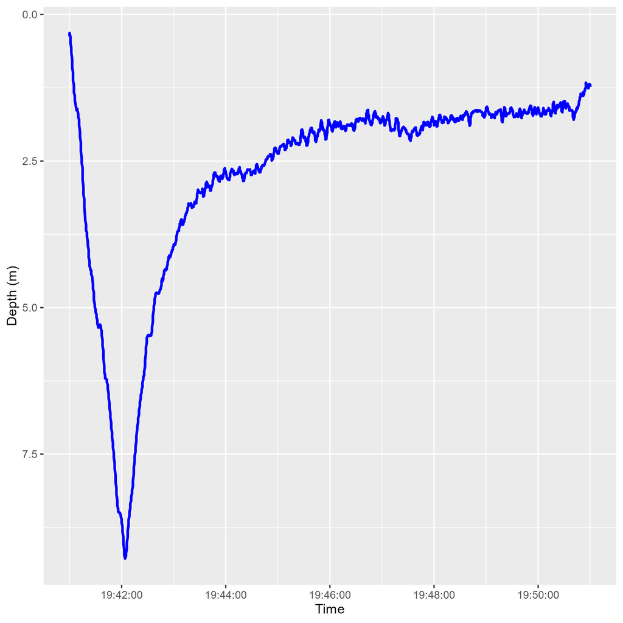

Plankton tow depth profile #1

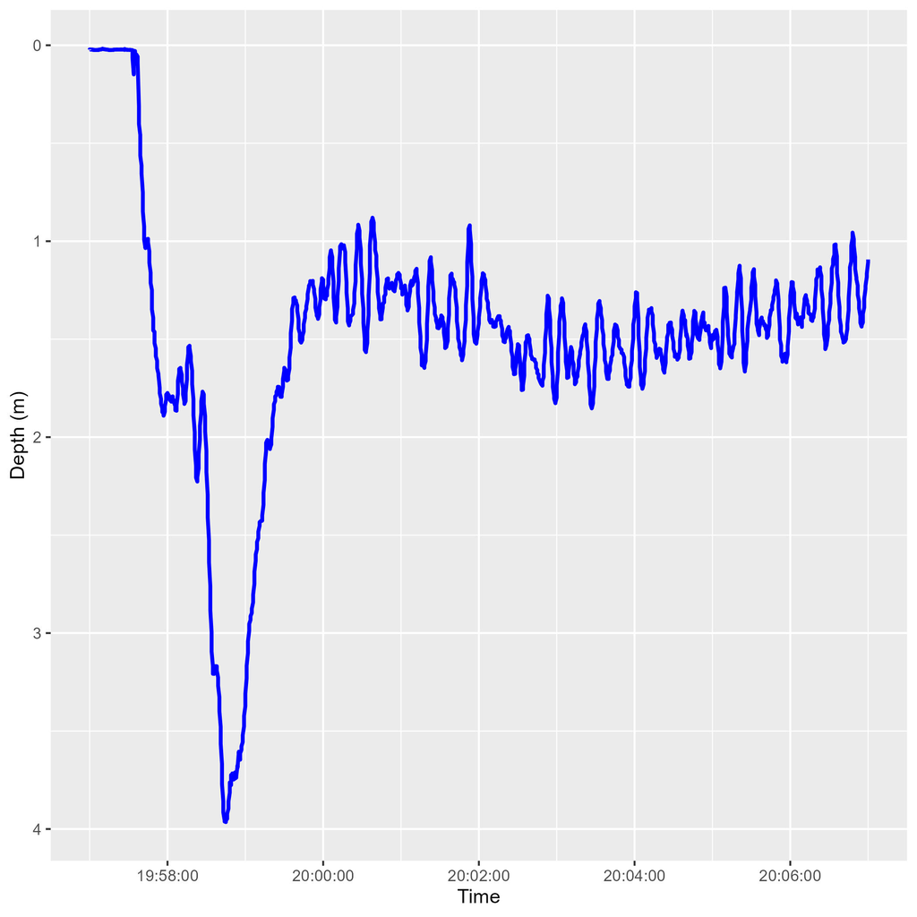

Plankton tow depth profile #2

The first tow is GB2023-07, which was with the tide and had an average depth of 2.7429252m. The second tow is GB2023-08, which was against the tide and had an average depth of 1.4830869m.

#### Captured plankton

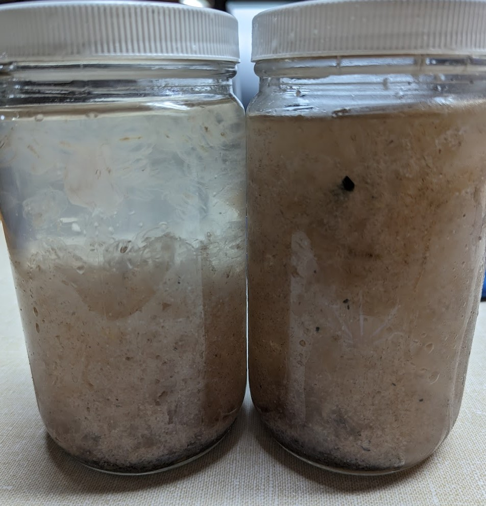

Captured plankton from the surface tows

### CTD Data

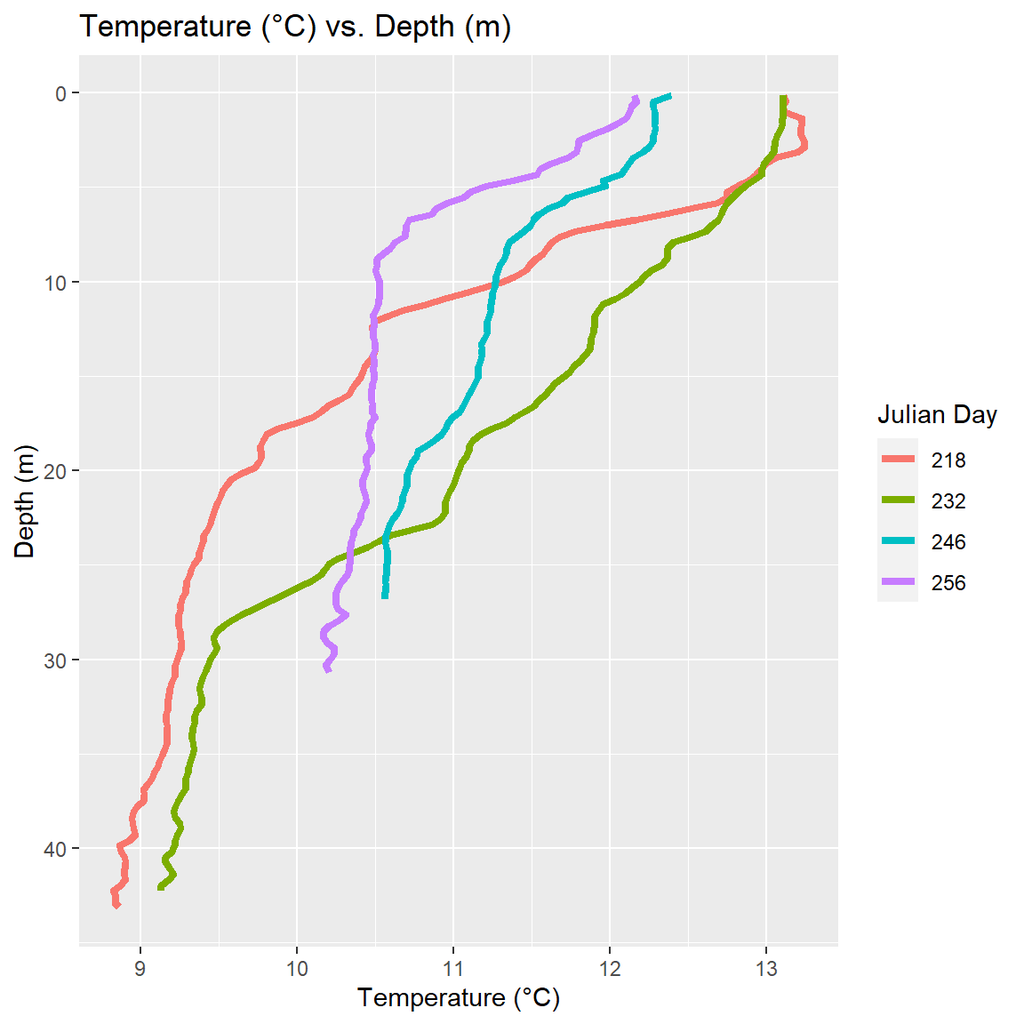

CTD depth profiles for all 2023 German Bank surveys so far.

#### Sea surface temperatures

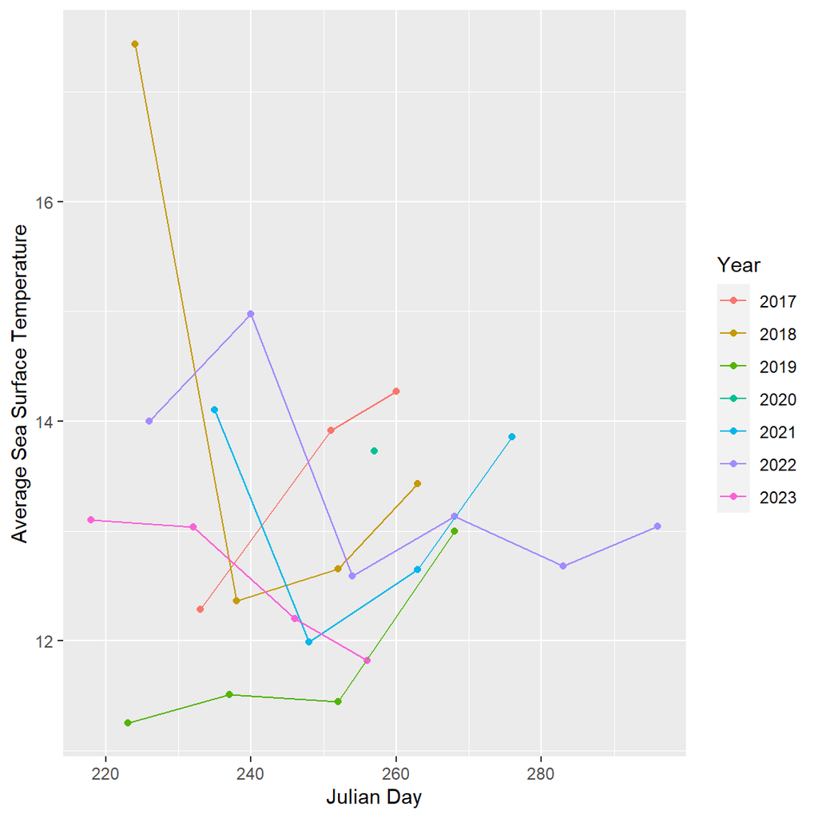

Annual average sea surface temperatures (SST) for German Bank.

## Vessel Performance

### Speed

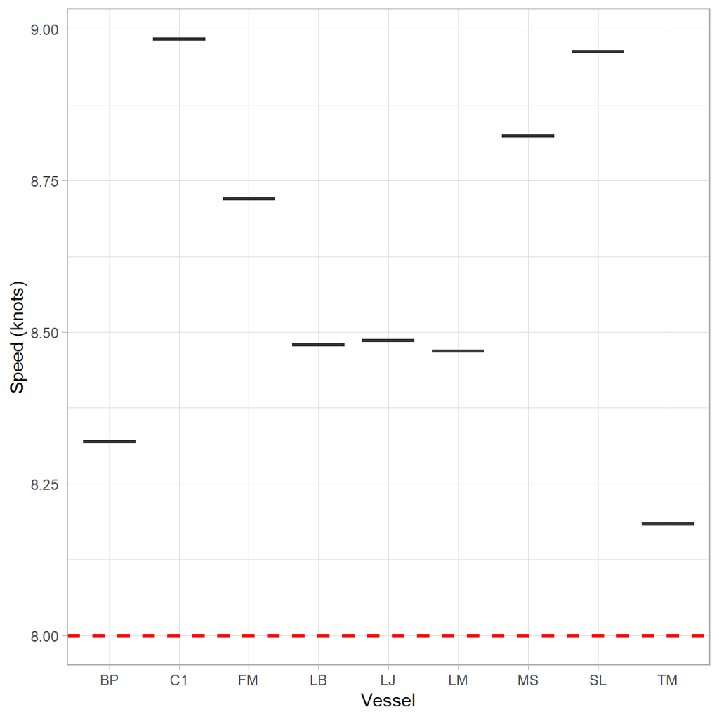

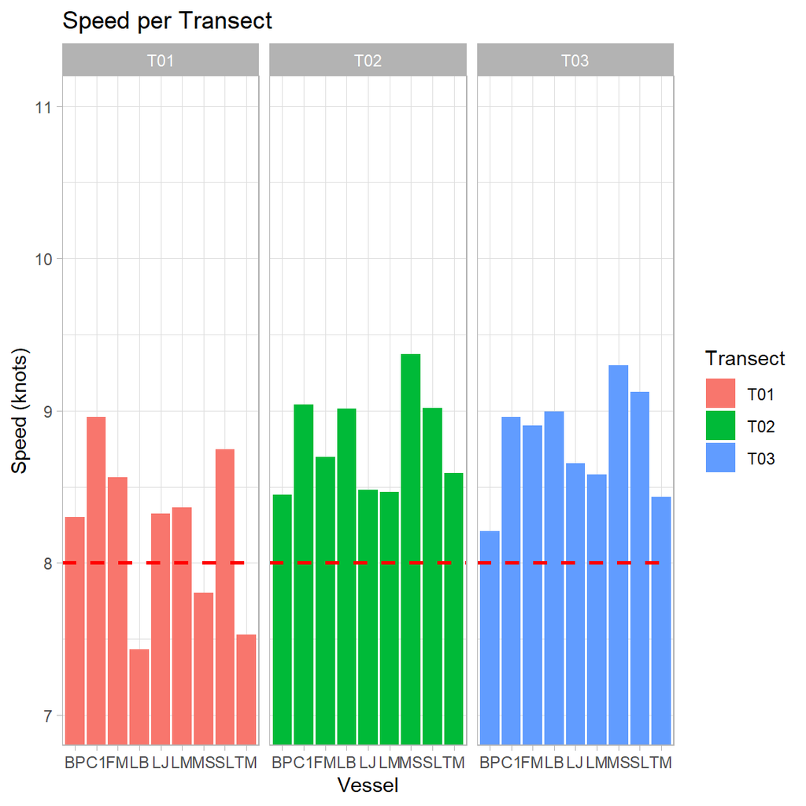

Average vessel speed was 8.6. This is above the 8 knot requirement; vessels are urged to slow down to prevent backscatter noise from interfering with the acoustic data.

### Distance

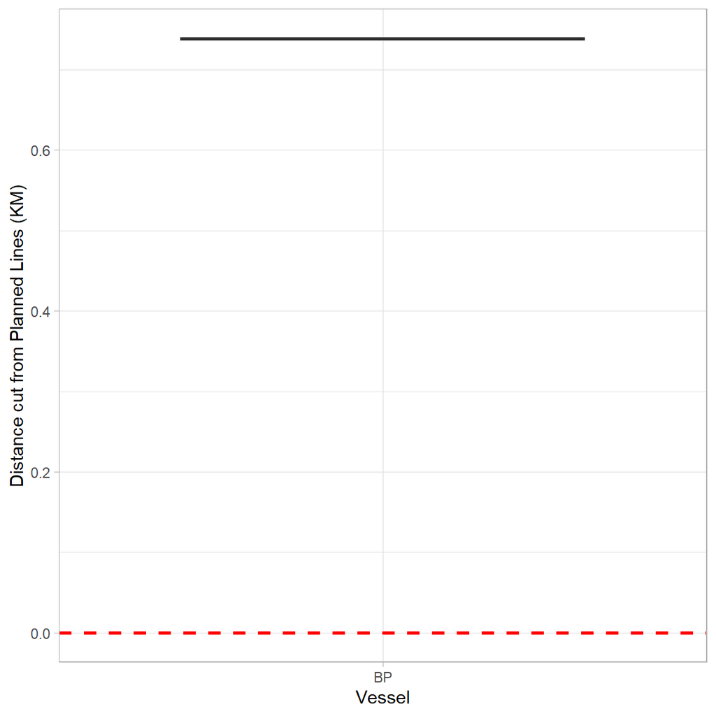